# Risk Factor Analysis

## Outcome Variable

**Outcome Variable:** sstunted

## Predictor Variables

**Intervention Variable:** parity

**Adjustment Set:**

unadjusted

## Stratifying Variables

The analysis was stratified on these variable(s):

- agecat
- studyid

The following strata were considered:

- agecat: 12 months, studyid: ki1000304b-SAS-FoodSuppl
- agecat: 12 months, studyid: ki1017093b-PROVIDE
- agecat: 12 months, studyid: ki1066203-TanzaniaChild2
- agecat: 12 months, studyid: ki1101329-Keneba
- agecat: 12 months, studyid: ki1113344-GMS-Nepal
- agecat: 12 months, studyid: ki1126311-ZVITAMBO
- agecat: 12 months, studyid: ki1135781-COHORTS
- agecat: 18 months, studyid: ki1000304b-SAS-FoodSuppl
- agecat: 18 months, studyid: ki1017093b-PROVIDE
- agecat: 18 months, studyid: ki1066203-TanzaniaChild2
- agecat: 18 months, studyid: ki1101329-Keneba
- agecat: 18 months, studyid: ki1113344-GMS-Nepal
- agecat: 18 months, studyid: ki1126311-ZVITAMBO
- agecat: 18 months, studyid: ki1135781-COHORTS
- agecat: 24 months, studyid: ki1017093b-PROVIDE
- agecat: 24 months, studyid: ki1066203-TanzaniaChild2
- agecat: 24 months, studyid: ki1101329-Keneba
- agecat: 24 months, studyid: ki1113344-GMS-Nepal
- agecat: 24 months, studyid: ki1126311-ZVITAMBO
- agecat: 24 months, studyid: ki1135781-COHORTS
- agecat: 3 months, studyid: ki1000304b-SAS-FoodSuppl
- agecat: 3 months, studyid: ki1017093b-PROVIDE
- agecat: 3 months, studyid: ki1066203-TanzaniaChild2
- agecat: 3 months, studyid: ki1101329-Keneba
- agecat: 3 months, studyid: ki1113344-GMS-Nepal
- agecat: 3 months, studyid: ki1126311-ZVITAMBO
- agecat: 3 months, studyid: ki1135781-COHORTS
- agecat: 6 months, studyid: ki1000304b-SAS-FoodSuppl
- agecat: 6 months, studyid: ki1017093b-PROVIDE
- agecat: 6 months, studyid: ki1066203-TanzaniaChild2
- agecat: 6 months, studyid: ki1101329-Keneba
- agecat: 6 months, studyid: ki1113344-GMS-Nepal
- agecat: 6 months, studyid: ki1126311-ZVITAMBO
- agecat: 6 months, studyid: ki1135781-COHORTS
- agecat: 9 months, studyid: ki1000304b-SAS-FoodSuppl
- agecat: 9 months, studyid: ki1017093b-PROVIDE
- agecat: 9 months, studyid: ki1066203-TanzaniaChild2
- agecat: 9 months, studyid: ki1101329-Keneba
- agecat: 9 months, studyid: ki1113344-GMS-Nepal
- agecat: 9 months, studyid: ki1126311-ZVITAMBO
- agecat: 9 months, studyid: ki1135781-COHORTS
- agecat: Birth, studyid: ki1101329-Keneba
- agecat: Birth, studyid: ki1126311-ZVITAMBO
- agecat: Birth, studyid: ki1135781-COHORTS

### Dropped Strata

Some strata were dropped due to rare outcomes:

- agecat: Birth, studyid: ki1101329-Keneba
- agecat: 3 months, studyid: ki1000304b-SAS-FoodSuppl
- agecat: 3 months, studyid: ki1017093b-PROVIDE
- agecat: 3 months, studyid: ki1066203-TanzaniaChild2
- agecat: 3 months, studyid: ki1101329-Keneba
- agecat: 6 months, studyid: ki1000304b-SAS-FoodSuppl
- agecat: 6 months, studyid: ki1017093b-PROVIDE
- agecat: 6 months, studyid: ki1066203-TanzaniaChild2
- agecat: 6 months, studyid: ki1101329-Keneba
- agecat: 9 months, studyid: ki1000304b-SAS-FoodSuppl
- agecat: 9 months, studyid: ki1017093b-PROVIDE
- agecat: 9 months, studyid: ki1066203-TanzaniaChild2
- agecat: 9 months, studyid: ki1101329-Keneba
- agecat: 12 months, studyid: ki1017093b-PROVIDE
- agecat: 12 months, studyid: ki1066203-TanzaniaChild2
- agecat: 12 months, studyid: ki1101329-Keneba
- agecat: 18 months, studyid: ki1017093b-PROVIDE
- agecat: 18 months, studyid: ki1066203-TanzaniaChild2
- agecat: 18 months, studyid: ki1101329-Keneba
- agecat: 24 months, studyid: ki1017093b-PROVIDE
- agecat: 24 months, studyid: ki1066203-TanzaniaChild2
- agecat: 24 months, studyid: ki1101329-Keneba

## Methods Detail

We’re interested in the causal parameters $E[Y_a]$ for all values of $a \in \mathcal{A}$. These parameters represent the mean outcome if, possibly contrary to fact, we intervened to set all units to have $A=a$. Under the randomization and positivity assumptions, these are identified by the statistical parameters $\psi_a=E_W[E_{Y|A,W}(Y|A=a,W)]$. In addition, we’re interested in the mean of $Y$, $E[Y]$ under no intervention (the observed mean). We will estimate these parameters by using SuperLearner to fit the relevant likelihood factors – $E_{Y|A,W}(Y|A=a,W)$ and $p(A=a|W)$, and then updating our likelihood fit using a joint TMLE.

For unadjusted analyses ($W=\{\}$), initial likelihoods were estimated using Lrnr_glm to estimate the simple $E(Y|A)$ and Lrnr_mean to estimate $p(A)$. For adjusted analyses, a small library containing Lrnr_glmnet, Lrnr_xgboost, and Lrnr_mean was used.

Having estimated these parameters, we will then use the delta method to estimate relative risks and attributable risks relative to a prespecified baseline level of $A$.

# Results Detail

## Results Plots

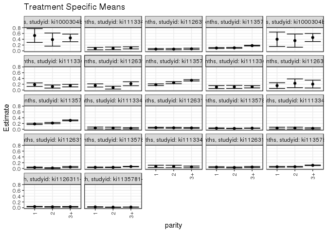

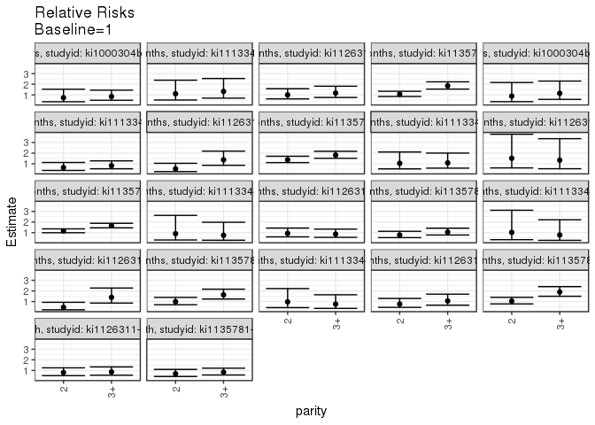

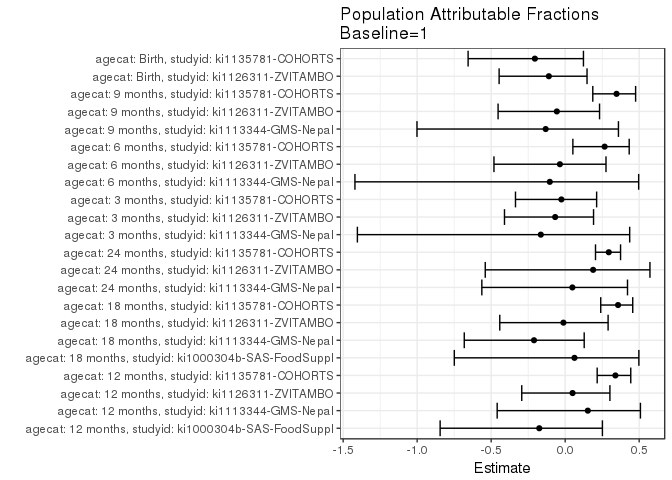

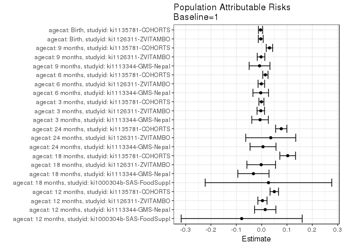

## Data Summary

| agecat | studyid | A | n | nA | nAY0 | nAY1 |
| --- | --- | --- | --- | --- | --- | --- |
| Birth | ki1000304b-SAS-FoodSuppl | 1 | 0 | 0 | 0 | 0 |
| Birth | ki1000304b-SAS-FoodSuppl | 2 | 0 | 0 | 0 | 0 |
| Birth | ki1000304b-SAS-FoodSuppl | 3+ | 0 | 0 | 0 | 0 |
| Birth | ki1017093b-PROVIDE | 1 | 0 | 0 | 0 | 0 |
| Birth | ki1017093b-PROVIDE | 2 | 0 | 0 | 0 | 0 |
| Birth | ki1017093b-PROVIDE | 3+ | 0 | 0 | 0 | 0 |
| Birth | ki1066203-TanzaniaChild2 | 1 | 0 | 0 | 0 | 0 |
| Birth | ki1066203-TanzaniaChild2 | 2 | 0 | 0 | 0 | 0 |
| Birth | ki1066203-TanzaniaChild2 | 3+ | 0 | 0 | 0 | 0 |
| Birth | ki1101329-Keneba | 1 | 1407 | 156 | 153 | 3 |
| Birth | ki1101329-Keneba | 2 | 1407 | 146 | 144 | 2 |
| Birth | ki1101329-Keneba | 3+ | 1407 | 1105 | 1084 | 21 |
| Birth | ki1113344-GMS-Nepal | 1 | 0 | 0 | 0 | 0 |
| Birth | ki1113344-GMS-Nepal | 2 | 0 | 0 | 0 | 0 |
| Birth | ki1113344-GMS-Nepal | 3+ | 0 | 0 | 0 | 0 |
| Birth | ki1126311-ZVITAMBO | 1 | 3449 | 1470 | 1417 | 53 |
| Birth | ki1126311-ZVITAMBO | 2 | 3449 | 1009 | 980 | 29 |
| Birth | ki1126311-ZVITAMBO | 3+ | 3449 | 970 | 940 | 30 |
| Birth | ki1135781-COHORTS | 1 | 7579 | 1428 | 1391 | 37 |
| Birth | ki1135781-COHORTS | 2 | 7579 | 1794 | 1762 | 32 |
| Birth | ki1135781-COHORTS | 3+ | 7579 | 4357 | 4263 | 94 |
| 3 months | ki1000304b-SAS-FoodSuppl | 1 | 93 | 17 | 14 | 3 |
| 3 months | ki1000304b-SAS-FoodSuppl | 2 | 93 | 19 | 18 | 1 |
| 3 months | ki1000304b-SAS-FoodSuppl | 3+ | 93 | 57 | 49 | 8 |
| 3 months | ki1017093b-PROVIDE | 1 | 168 | 68 | 65 | 3 |
| 3 months | ki1017093b-PROVIDE | 2 | 168 | 58 | 56 | 2 |
| 3 months | ki1017093b-PROVIDE | 3+ | 168 | 42 | 42 | 0 |
| 3 months | ki1066203-TanzaniaChild2 | 1 | 567 | 197 | 192 | 5 |
| 3 months | ki1066203-TanzaniaChild2 | 2 | 567 | 193 | 190 | 3 |
| 3 months | ki1066203-TanzaniaChild2 | 3+ | 567 | 177 | 175 | 2 |

[output cut: 117 more lines]

## Results Table

### Parameter: TSM

| agecat | studyid | intervention_level | baseline_level | estimate | ci_lower | ci_upper |
| --- | --- | --- | --- | --- | --- | --- |
| Birth | ki1126311-ZVITAMBO | 1 | NA | 0.0360544 | 0.0265230 | 0.0455858 |
| Birth | ki1126311-ZVITAMBO | 2 | NA | 0.0287413 | 0.0184307 | 0.0390520 |
| Birth | ki1126311-ZVITAMBO | 3+ | NA | 0.0309278 | 0.0200316 | 0.0418241 |
| Birth | ki1135781-COHORTS | 1 | NA | 0.0259104 | 0.0176700 | 0.0341508 |
| Birth | ki1135781-COHORTS | 2 | NA | 0.0178372 | 0.0117120 | 0.0239624 |
| Birth | ki1135781-COHORTS | 3+ | NA | 0.0215745 | 0.0172601 | 0.0258888 |
| 3 months | ki1113344-GMS-Nepal | 1 | NA | 0.0448718 | 0.0123568 | 0.0773868 |
| 3 months | ki1113344-GMS-Nepal | 2 | NA | 0.0405405 | 0.0087384 | 0.0723427 |
| 3 months | ki1113344-GMS-Nepal | 3+ | NA | 0.0337079 | 0.0120412 | 0.0553746 |
| 3 months | ki1126311-ZVITAMBO | 1 | NA | 0.0535918 | 0.0386833 | 0.0685002 |
| 3 months | ki1126311-ZVITAMBO | 2 | NA | 0.0499266 | 0.0335654 | 0.0662878 |
| 3 months | ki1126311-ZVITAMBO | 3+ | NA | 0.0462833 | 0.0308585 | 0.0617082 |
| 3 months | ki1135781-COHORTS | 1 | NA | 0.0371930 | 0.0273672 | 0.0470188 |
| 3 months | ki1135781-COHORTS | 2 | NA | 0.0288200 | 0.0211732 | 0.0364669 |
| 3 months | ki1135781-COHORTS | 3+ | NA | 0.0390397 | 0.0333530 | 0.0447264 |
| 6 months | ki1113344-GMS-Nepal | 1 | NA | 0.0392157 | 0.0084312 | 0.0700001 |
| 6 months | ki1113344-GMS-Nepal | 2 | NA | 0.0402685 | 0.0086749 | 0.0718620 |
| 6 months | ki1113344-GMS-Nepal | 3+ | NA | 0.0306513 | 0.0097209 | 0.0515818 |
| 6 months | ki1126311-ZVITAMBO | 1 | NA | 0.0363409 | 0.0233538 | 0.0493279 |
| 6 months | ki1126311-ZVITAMBO | 2 | NA | 0.0165837 | 0.0063883 | 0.0267792 |
| 6 months | ki1126311-ZVITAMBO | 3+ | NA | 0.0506912 | 0.0338361 | 0.0675464 |
| 6 months | ki1135781-COHORTS | 1 | NA | 0.0404917 | 0.0301027 | 0.0508807 |
| 6 months | ki1135781-COHORTS | 2 | NA | 0.0399101 | 0.0308133 | 0.0490068 |
| 6 months | ki1135781-COHORTS | 3+ | NA | 0.0662637 | 0.0588293 | 0.0736980 |
| 9 months | ki1113344-GMS-Nepal | 1 | NA | 0.0718954 | 0.0309273 | 0.1128635 |
| 9 months | ki1113344-GMS-Nepal | 2 | NA | 0.0699301 | 0.0280927 | 0.1117674 |
| 9 months | ki1113344-GMS-Nepal | 3+ | NA | 0.0549020 | 0.0269183 | 0.0828856 |
| 9 months | ki1126311-ZVITAMBO | 1 | NA | 0.0468140 | 0.0318802 | 0.0617479 |
| 9 months | ki1126311-ZVITAMBO | 2 | NA | 0.0357143 | 0.0207107 | 0.0507178 |
| 9 months | ki1126311-ZVITAMBO | 3+ | NA | 0.0495050 | 0.0322298 | 0.0667801 |
| 9 months | ki1135781-COHORTS | 1 | NA | 0.0579151 | 0.0451922 | 0.0706379 |
| 9 months | ki1135781-COHORTS | 2 | NA | 0.0602484 | 0.0486247 | 0.0718722 |
| 9 months | ki1135781-COHORTS | 3+ | NA | 0.1099528 | 0.1002925 | 0.1196131 |
| 12 months | ki1000304b-SAS-FoodSuppl | 1 | NA | 0.5294118 | 0.2908283 | 0.7679953 |
| 12 months | ki1000304b-SAS-FoodSuppl | 2 | NA | 0.3888889 | 0.1624327 | 0.6153450 |
| 12 months | ki1000304b-SAS-FoodSuppl | 3+ | NA | 0.4464286 | 0.3155055 | 0.5773517 |
| 12 months | ki1113344-GMS-Nepal | 1 | NA | 0.0774194 | 0.0353081 | 0.1195307 |
| 12 months | ki1113344-GMS-Nepal | 2 | NA | 0.0857143 | 0.0393011 | 0.1321274 |
| 12 months | ki1113344-GMS-Nepal | 3+ | NA | 0.1026616 | 0.0659467 | 0.1393765 |
| 12 months | ki1126311-ZVITAMBO | 1 | NA | 0.0586420 | 0.0405465 | 0.0767375 |
| 12 months | ki1126311-ZVITAMBO | 2 | NA | 0.0582524 | 0.0380177 | 0.0784871 |
| 12 months | ki1126311-ZVITAMBO | 3+ | NA | 0.0687732 | 0.0473827 | 0.0901638 |
| 12 months | ki1135781-COHORTS | 1 | NA | 0.0969845 | 0.0804246 | 0.1135444 |
| 12 months | ki1135781-COHORTS | 2 | NA | 0.1032864 | 0.0878377 | 0.1187350 |
| 12 months | ki1135781-COHORTS | 3+ | NA | 0.1798165 | 0.1676293 | 0.1920037 |
| 18 months | ki1000304b-SAS-FoodSuppl | 1 | NA | 0.4000000 | 0.1505563 | 0.6494437 |
| 18 months | ki1000304b-SAS-FoodSuppl | 2 | NA | 0.3529412 | 0.1243755 | 0.5815069 |
| 18 months | ki1000304b-SAS-FoodSuppl | 3+ | NA | 0.4600000 | 0.3210037 | 0.5989963 |
| 18 months | ki1113344-GMS-Nepal | 1 | NA | 0.1870968 | 0.1256456 | 0.2485479 |
| 18 months | ki1113344-GMS-Nepal | 2 | NA | 0.1205674 | 0.0667714 | 0.1743634 |
| 18 months | ki1113344-GMS-Nepal | 3+ | NA | 0.1535433 | 0.1091677 | 0.1979189 |
| 18 months | ki1126311-ZVITAMBO | 1 | NA | 0.1595092 | 0.1032329 | 0.2157855 |
| 18 months | ki1126311-ZVITAMBO | 2 | NA | 0.0833333 | 0.0338243 | 0.1328423 |
| 18 months | ki1126311-ZVITAMBO | 3+ | NA | 0.2183099 | 0.1502847 | 0.2863350 |
| 18 months | ki1135781-COHORTS | 1 | NA | 0.1848185 | 0.1539094 | 0.2157275 |
| 18 months | ki1135781-COHORTS | 2 | NA | 0.2544861 | 0.2199994 | 0.2889729 |
| 18 months | ki1135781-COHORTS | 3+ | NA | 0.3358689 | 0.3134733 | 0.3582645 |
| 24 months | ki1113344-GMS-Nepal | 1 | NA | 0.1029412 | 0.0518178 | 0.1540645 |
| 24 months | ki1113344-GMS-Nepal | 2 | NA | 0.1076923 | 0.0543512 | 0.1610334 |
| 24 months | ki1113344-GMS-Nepal | 3+ | NA | 0.1115880 | 0.0711191 | 0.1520569 |
| 24 months | ki1126311-ZVITAMBO | 1 | NA | 0.1538462 | 0.0553556 | 0.2523367 |
| 24 months | ki1126311-ZVITAMBO | 2 | NA | 0.2333333 | 0.0813279 | 0.3853388 |
| 24 months | ki1126311-ZVITAMBO | 3+ | NA | 0.2058824 | 0.0693798 | 0.3423849 |
| 24 months | ki1135781-COHORTS | 1 | NA | 0.1849662 | 0.1628485 | 0.2070839 |
| 24 months | ki1135781-COHORTS | 2 | NA | 0.2146739 | 0.1936969 | 0.2356509 |
| 24 months | ki1135781-COHORTS | 3+ | NA | 0.3059621 | 0.2910926 | 0.3208315 |

### Parameter: E(Y)

| agecat | studyid | intervention_level | baseline_level | estimate | ci_lower | ci_upper |
| --- | --- | --- | --- | --- | --- | --- |
| Birth | ki1126311-ZVITAMBO | NA | NA | 0.0324732 | 0.0323665 | 0.0325798 |
| Birth | ki1135781-COHORTS | NA | NA | 0.0215068 | 0.0214479 | 0.0215657 |
| 3 months | ki1113344-GMS-Nepal | NA | NA | 0.0385289 | 0.0381360 | 0.0389218 |
| 3 months | ki1126311-ZVITAMBO | NA | NA | 0.0501982 | 0.0500728 | 0.0503235 |
| 3 months | ki1135781-COHORTS | NA | NA | 0.0362647 | 0.0361706 | 0.0363589 |
| 6 months | ki1113344-GMS-Nepal | NA | NA | 0.0355240 | 0.0351481 | 0.0358998 |
| 6 months | ki1126311-ZVITAMBO | NA | NA | 0.0350877 | 0.0345096 | 0.0356659 |
| 6 months | ki1135781-COHORTS | NA | NA | 0.0552057 | 0.0549130 | 0.0554983 |
| 9 months | ki1113344-GMS-Nepal | NA | NA | 0.0635209 | 0.0628496 | 0.0641921 |
| 9 months | ki1126311-ZVITAMBO | NA | NA | 0.0443199 | 0.0440660 | 0.0445738 |
| 9 months | ki1135781-COHORTS | NA | NA | 0.0886934 | 0.0881038 | 0.0892830 |
| 12 months | ki1000304b-SAS-FoodSuppl | NA | NA | 0.4505495 | 0.4414865 | 0.4596124 |
| 12 months | ki1113344-GMS-Nepal | NA | NA | 0.0913978 | 0.0904799 | 0.0923158 |
| 12 months | ki1126311-ZVITAMBO | NA | NA | 0.0617284 | 0.0615005 | 0.0619563 |
| 12 months | ki1135781-COHORTS | NA | NA | 0.1467932 | 0.1458432 | 0.1477433 |
| 18 months | ki1000304b-SAS-FoodSuppl | NA | NA | 0.4268293 | 0.4172511 | 0.4364074 |
| 18 months | ki1113344-GMS-Nepal | NA | NA | 0.1545455 | 0.1525049 | 0.1565860 |
| 18 months | ki1126311-ZVITAMBO | NA | NA | 0.1576471 | 0.1526192 | 0.1626749 |
| 18 months | ki1135781-COHORTS | NA | NA | 0.2875683 | 0.2853422 | 0.2897944 |
| 24 months | ki1113344-GMS-Nepal | NA | NA | 0.1082164 | 0.1079002 | 0.1085327 |
| 24 months | ki1126311-ZVITAMBO | NA | NA | 0.1896552 | 0.1834697 | 0.1958407 |
| 24 months | ki1135781-COHORTS | NA | NA | 0.2622124 | 0.2609220 | 0.2635028 |

### Parameter: RR

| agecat | studyid | intervention_level | baseline_level | estimate | ci_lower | ci_upper |
| --- | --- | --- | --- | --- | --- | --- |
| Birth | ki1126311-ZVITAMBO | 2 | 1 | 0.7971651 | 0.5105236 | 1.2447460 |
| Birth | ki1126311-ZVITAMBO | 3+ | 1 | 0.8578098 | 0.5522024 | 1.3325504 |
| Birth | ki1135781-COHORTS | 2 | 1 | 0.6884209 | 0.4311065 | 1.0993184 |
| Birth | ki1135781-COHORTS | 3+ | 1 | 0.8326582 | 0.5718872 | 1.2123366 |
| 3 months | ki1113344-GMS-Nepal | 2 | 1 | 0.9034749 | 0.3105468 | 2.6284827 |
| 3 months | ki1113344-GMS-Nepal | 3+ | 1 | 0.7512039 | 0.2851597 | 1.9789164 |
| 3 months | ki1126311-ZVITAMBO | 2 | 1 | 0.9316087 | 0.6061063 | 1.4319185 |
| 3 months | ki1126311-ZVITAMBO | 3+ | 1 | 0.8636269 | 0.5594900 | 1.3330916 |
| 3 months | ki1135781-COHORTS | 2 | 1 | 0.7748777 | 0.5328713 | 1.1267925 |
| 3 months | ki1135781-COHORTS | 3+ | 1 | 1.0496527 | 0.7762952 | 1.4192676 |
| 6 months | ki1113344-GMS-Nepal | 2 | 1 | 1.0268456 | 0.3384542 | 3.1153756 |
| 6 months | ki1113344-GMS-Nepal | 3+ | 1 | 0.7816092 | 0.2761410 | 2.2123227 |
| 6 months | ki1126311-ZVITAMBO | 2 | 1 | 0.4563390 | 0.2241084 | 0.9292169 |
| 6 months | ki1126311-ZVITAMBO | 3+ | 1 | 1.3948832 | 0.8561396 | 2.2726424 |
| 6 months | ki1135781-COHORTS | 2 | 1 | 0.9856360 | 0.6993101 | 1.3891954 |
| 6 months | ki1135781-COHORTS | 3+ | 1 | 1.6364757 | 1.2367864 | 2.1653317 |
| 9 months | ki1113344-GMS-Nepal | 2 | 1 | 0.9726637 | 0.4257361 | 2.2222092 |
| 9 months | ki1113344-GMS-Nepal | 3+ | 1 | 0.7636364 | 0.3555139 | 1.6402749 |
| 9 months | ki1126311-ZVITAMBO | 2 | 1 | 0.7628968 | 0.4501728 | 1.2928626 |
| 9 months | ki1126311-ZVITAMBO | 3+ | 1 | 1.0574807 | 0.6590831 | 1.6966990 |
| 9 months | ki1135781-COHORTS | 2 | 1 | 1.0402899 | 0.7765659 | 1.3935752 |
| 9 months | ki1135781-COHORTS | 3+ | 1 | 1.8985191 | 1.4985156 | 2.4052968 |
| 12 months | ki1000304b-SAS-FoodSuppl | 2 | 1 | 0.7345679 | 0.3517606 | 1.5339693 |
| 12 months | ki1000304b-SAS-FoodSuppl | 3+ | 1 | 0.8432540 | 0.4925468 | 1.4436745 |
| 12 months | ki1113344-GMS-Nepal | 2 | 1 | 1.1071429 | 0.5138981 | 2.3852304 |
| 12 months | ki1113344-GMS-Nepal | 3+ | 1 | 1.3260456 | 0.6915825 | 2.5425702 |
| 12 months | ki1126311-ZVITAMBO | 2 | 1 | 0.9933572 | 0.6241946 | 1.5808506 |
| 12 months | ki1126311-ZVITAMBO | 3+ | 1 | 1.1727646 | 0.7567162 | 1.8175596 |
| 12 months | ki1135781-COHORTS | 2 | 1 | 1.0649781 | 0.8487081 | 1.3363586 |
| 12 months | ki1135781-COHORTS | 3+ | 1 | 1.8540744 | 1.5429223 | 2.2279748 |
| 18 months | ki1000304b-SAS-FoodSuppl | 2 | 1 | 0.8823529 | 0.3590815 | 2.1681616 |
| 18 months | ki1000304b-SAS-FoodSuppl | 3+ | 1 | 1.1500000 | 0.5751080 | 2.2995680 |
| 18 months | ki1113344-GMS-Nepal | 2 | 1 | 0.6444118 | 0.3702936 | 1.1214524 |
| 18 months | ki1113344-GMS-Nepal | 3+ | 1 | 0.8206625 | 0.5298611 | 1.2710631 |
| 18 months | ki1126311-ZVITAMBO | 2 | 1 | 0.5224359 | 0.2617875 | 1.0425985 |
| 18 months | ki1126311-ZVITAMBO | 3+ | 1 | 1.3686349 | 0.8547927 | 2.1913635 |
| 18 months | ki1135781-COHORTS | 2 | 1 | 1.3769518 | 1.1102884 | 1.7076610 |
| 18 months | ki1135781-COHORTS | 3+ | 1 | 1.8172908 | 1.5178639 | 2.1757853 |
| 24 months | ki1113344-GMS-Nepal | 2 | 1 | 1.0461538 | 0.5187748 | 2.1096587 |
| 24 months | ki1113344-GMS-Nepal | 3+ | 1 | 1.0839975 | 0.5860828 | 2.0049225 |
| 24 months | ki1126311-ZVITAMBO | 2 | 1 | 1.5166667 | 0.6084458 | 3.7805799 |
| 24 months | ki1126311-ZVITAMBO | 3+ | 1 | 1.3382353 | 0.5324365 | 3.3635440 |
| 24 months | ki1135781-COHORTS | 2 | 1 | 1.1606115 | 0.9945372 | 1.3544179 |
| 24 months | ki1135781-COHORTS | 3+ | 1 | 1.6541510 | 1.4538456 | 1.8820538 |

### Parameter: PAR

| agecat | studyid | intervention_level | baseline_level | estimate | ci_lower | ci_upper |
| --- | --- | --- | --- | --- | --- | --- |
| Birth | ki1126311-ZVITAMBO | 1 | NA | -0.0035812 | -0.0131133 | 0.0059508 |
| Birth | ki1135781-COHORTS | 1 | NA | -0.0044036 | -0.0126442 | 0.0038371 |
| 3 months | ki1113344-GMS-Nepal | 1 | NA | -0.0063429 | -0.0388603 | 0.0261745 |
| 3 months | ki1126311-ZVITAMBO | 1 | NA | -0.0033936 | -0.0183026 | 0.0115153 |
| 3 months | ki1135781-COHORTS | 1 | NA | -0.0009282 | -0.0107545 | 0.0088980 |
| 6 months | ki1113344-GMS-Nepal | 1 | NA | -0.0036917 | -0.0344784 | 0.0270950 |
| 6 months | ki1126311-ZVITAMBO | 1 | NA | -0.0012531 | -0.0142531 | 0.0117468 |
| 6 months | ki1135781-COHORTS | 1 | NA | 0.0147140 | 0.0043209 | 0.0251071 |
| 9 months | ki1113344-GMS-Nepal | 1 | NA | -0.0083746 | -0.0493482 | 0.0325991 |
| 9 months | ki1126311-ZVITAMBO | 1 | NA | -0.0024941 | -0.0174302 | 0.0124419 |
| 9 months | ki1135781-COHORTS | 1 | NA | 0.0307783 | 0.0180418 | 0.0435149 |
| 12 months | ki1000304b-SAS-FoodSuppl | 1 | NA | -0.0788623 | -0.3176179 | 0.1598933 |
| 12 months | ki1113344-GMS-Nepal | 1 | NA | 0.0139785 | -0.0281428 | 0.0560998 |
| 12 months | ki1126311-ZVITAMBO | 1 | NA | 0.0030864 | -0.0150105 | 0.0211833 |
| 12 months | ki1135781-COHORTS | 1 | NA | 0.0498087 | 0.0332216 | 0.0663958 |
| 18 months | ki1000304b-SAS-FoodSuppl | 1 | NA | 0.0268293 | -0.2227982 | 0.2764568 |
| 18 months | ki1113344-GMS-Nepal | 1 | NA | -0.0325513 | -0.0940363 | 0.0289337 |
| 18 months | ki1126311-ZVITAMBO | 1 | NA | -0.0018621 | -0.0583625 | 0.0546383 |
| 18 months | ki1135781-COHORTS | 1 | NA | 0.1027498 | 0.0717607 | 0.1337389 |
| 24 months | ki1113344-GMS-Nepal | 1 | NA | 0.0052753 | -0.0458491 | 0.0563996 |
| 24 months | ki1126311-ZVITAMBO | 1 | NA | 0.0358090 | -0.0628756 | 0.1344936 |
| 24 months | ki1135781-COHORTS | 1 | NA | 0.0772462 | 0.0550909 | 0.0994015 |

### Parameter: PAF

| agecat | studyid | intervention_level | baseline_level | estimate | ci_lower | ci_upper |
| --- | --- | --- | --- | --- | --- | --- |
| Birth | ki1126311-ZVITAMBO | 1 | NA | -0.1102830 | -0.4462841 | 0.1476582 |
| Birth | ki1135781-COHORTS | 1 | NA | -0.2047524 | -0.6558612 | 0.1234601 |
| 3 months | ki1113344-GMS-Nepal | 1 | NA | -0.1646270 | -1.4039014 | 0.4357688 |
| 3 months | ki1126311-ZVITAMBO | 1 | NA | -0.0676049 | -0.4100344 | 0.1916650 |
| 3 months | ki1135781-COHORTS | 1 | NA | -0.0255965 | -0.3357220 | 0.2125247 |
| 6 months | ki1113344-GMS-Nepal | 1 | NA | -0.1039216 | -1.4204258 | 0.4965172 |
| 6 months | ki1126311-ZVITAMBO | 1 | NA | -0.0357143 | -0.4811811 | 0.2757779 |
| 6 months | ki1135781-COHORTS | 1 | NA | 0.2665305 | 0.0519457 | 0.4325457 |
| 9 months | ki1113344-GMS-Nepal | 1 | NA | -0.1318394 | -1.0012485 | 0.3598694 |
| 9 months | ki1126311-ZVITAMBO | 1 | NA | -0.0562755 | -0.4532532 | 0.2322618 |
| 9 months | ki1135781-COHORTS | 1 | NA | 0.3470195 | 0.1865134 | 0.4758567 |
| 12 months | ki1000304b-SAS-FoodSuppl | 1 | NA | -0.1750359 | -0.8448631 | 0.2515926 |
| 12 months | ki1113344-GMS-Nepal | 1 | NA | 0.1529412 | -0.4594290 | 0.5083634 |
| 12 months | ki1126311-ZVITAMBO | 1 | NA | 0.0500000 | -0.2934386 | 0.3022475 |
| 12 months | ki1135781-COHORTS | 1 | NA | 0.3393119 | 0.2162012 | 0.4430858 |
| 18 months | ki1000304b-SAS-FoodSuppl | 1 | NA | 0.0628571 | -0.7490858 | 0.4978881 |
| 18 months | ki1113344-GMS-Nepal | 1 | NA | -0.2106262 | -0.6817733 | 0.1285295 |
| 18 months | ki1126311-ZVITAMBO | 1 | NA | -0.0118121 | -0.4419412 | 0.2900101 |
| 18 months | ki1135781-COHORTS | 1 | NA | 0.3573058 | 0.2401750 | 0.4563803 |
| 24 months | ki1113344-GMS-Nepal | 1 | NA | 0.0487473 | -0.5630826 | 0.4210915 |
| 24 months | ki1126311-ZVITAMBO | 1 | NA | 0.1888112 | -0.5399720 | 0.5727018 |
| 24 months | ki1135781-COHORTS | 1 | NA | 0.2945940 | 0.2049127 | 0.3741597 |